# Session 10: Consequences of affective polarization for democracy

Tristan Muno

November 25, 2026

## Session 10 goals

By the end of today, you will be able to:

1. Reconstruct the argument for why AP is supposed to harm democracy.
2. Name the consequences that have actually been studied, and the designs used to study them.
3. Distinguish findings that hold up from findings that depend on context or on measurement.

## Today

1. **Back to the lecture**
2. **Part 1: The alarm**
   - Why AP should harm democracy
   - How would you test it?
3. **Part 2: Two readings, magic five**
   - Harteveld et al. (2026)
   - Janssen and Turkenburg (2024)
4. **Part 3: What holds up?**
5. **Wrap-up**

## Back to the lecture

The lecture ended on the divide between **cosmopolitans** and **communitarians**.

1. Does this divide produce AP, with **warmth** toward one’s own side and **dislike** of the other?
2. Is it the **main cleavage**, the one along which party, region, education and religion line up?

**Note**

**Session 07: social sorting.** When divides line up rather than cross, out-groups look different in every way, and AP rises.

Suppose it does produce AP. **Should we worry?**

# Part 1: The alarm

## The alarm

The claim that motivates the whole literature:

- Polarization as a **global crisis of democracy** (McCoy et al. 2018)
- AP **undermines** support for democratic norms (Kingzette et al. 2021)
- Citizens become “partisans first and democrats second” (Graham and Svolik 2020, 393)

**Important**

**Most of this evidence is correlational, and most of it comes from the US.**

## Mechanisms and doubts

**Why AP should harm democracy**

- **Threat**: the other side looks dangerous, so I deny them rights
- **Politicization of norms**: I endorse democratic rules in the abstract, but not when they help the side I hate

**Why it might not**

- US experiments lowered AP, and **social avoidance** fell (Broockman et al. 2023; Voelkel et al. 2023)
- But support for **democratic norms** did not move
- AP may shape only judgments that are **personal**, not judgments about institutions

## Prediction sketch

Alone, two minutes, on paper.

- Draw the line from **AP** (x axis, low to high) to **support for democracy** (y axis).
- Keep your sketch. We come back to it.

## Pair task

In pairs, four minutes. You want to know whether AP **causes** weaker support for democratic norms.

1. What do you **randomize**?
2. What do you **measure**, and when?
3. What could go **wrong**?

**Note**

**Session 06: potential outcomes.** We never see one person both polarized and not polarized. Random assignment still recovers the average effect.

## Exchange

**What we randomize, what we measure**

**What could go wrong**

# Harteveld et al. (2026)

## Introduction

- If we **lower** AP, do social relations and democratic attitudes improve?
- Depolarization programmes **assume** so, but the evidence is correlational, or from the US and null on norms
- A survey experiment in **nine democracies**: Brazil, France, Germany, Italy, Poland, Spain, Sweden, the UK, the US
- About **18,000** respondents, 2,000 per country, fielded in 2022

## Theory: two kinds of harm

Table 1: The seven alleged consequences, from the most interpersonal to the most system-oriented. Adapted from Harteveld et al. (2026), Table 1.

|  | Outcome | What it means here |
| --- | --- | --- |
| Horizontal (between citizens) | Avoidance | Keeping social distance from opponents |
|  | Aggression | Condoning harassment or violence against them |
| Hybrid | Discrimination | Unequal treatment in routine civic situations |
| Vertical (citizens and the system) | Opposition to compromise | Rejecting cooperation with the least-liked camp |
|  | Democratic norms | Rights for all, including disliked opponents |
|  | Dissatisfaction with democracy | How democracy works in one’s country |
|  | Political engagement | Likelihood of voting |

- Effects may differ by **institutions**, by how **entrenched** AP is, and by whether the out-group is a **stigmatized radical right**

## Research design

Three arms, randomly assigned:

- **Depolarizing**: “Research shows [in-party] and [out-party] supporters actually have quite a lot in common.” Write down three shared features.
- **Polarizing**: they have “very little” in common. Write down three differences.
- **Control**: neither
- AP: thermometer for the most-liked **minus** the least-liked party’s **supporters**

**Note**

**Session 05: horizontal and vertical AP.** Here AP is measured toward **citizens**, not parties (Druckman and Levendusky 2019), and keeps both components. **Session 07:** stressing what the groups share is social identity complexity in miniature.

## Did the manipulation work?

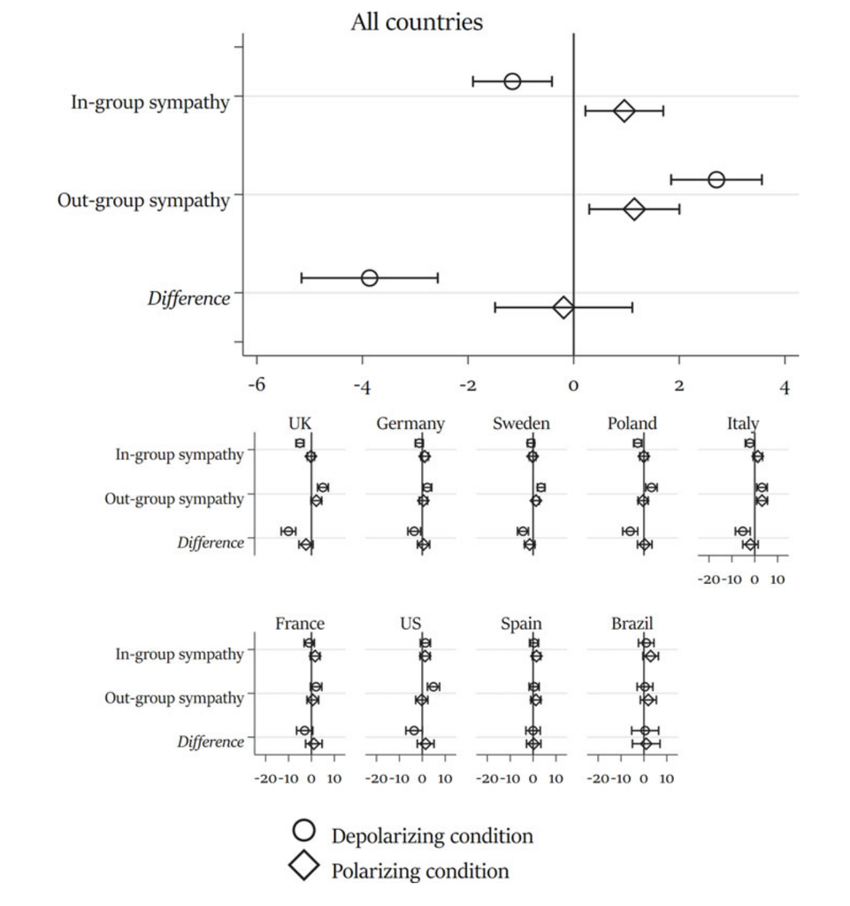

Figure 1: Effects of the depolarizing (circles) and polarizing (diamonds) prompts on in-group sympathy, out-group sympathy and their difference, relative to the control group, on the 0 to 100 thermometer. Top: all countries. Bottom: by country. *Source:* Harteveld et al. (2026), Figure 1.

- Depolarizing works in **6 of 9** countries, by 3 to 10 points
- Pooled about 4 points, a third of the gap between weak and strong partisans
- The **polarizing** prompt **failed**, so the comparison becomes depolarizing against control

**Note**

**Session 06: check the treatment first.** No movement in AP, no test of its consequences.

## Results: pooled

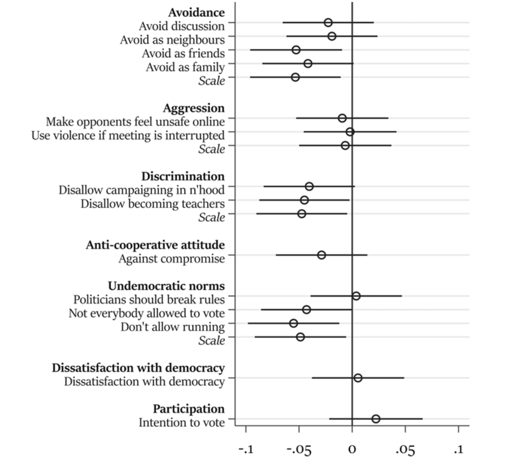

Figure 2: Effects of the depolarizing prompt on each outcome, pooled over nine countries. Values left of zero mean less avoidance, aggression, discrimination, opposition to compromise, undemocratic norms and dissatisfaction, and lower turnout intention. *Source:* Harteveld et al. (2026), Figure 2.

- In the cross-section, **every** outcome correlates with AP
- In the experiment, **avoidance** and **discrimination** fall
- Support for opponents’ right to run and for universal suffrage **rises**

. . .

- **Aggression**, **dissatisfaction** and **turnout** do not move
- Unlike the US studies, a **vertical** outcome moves

## Results: by country

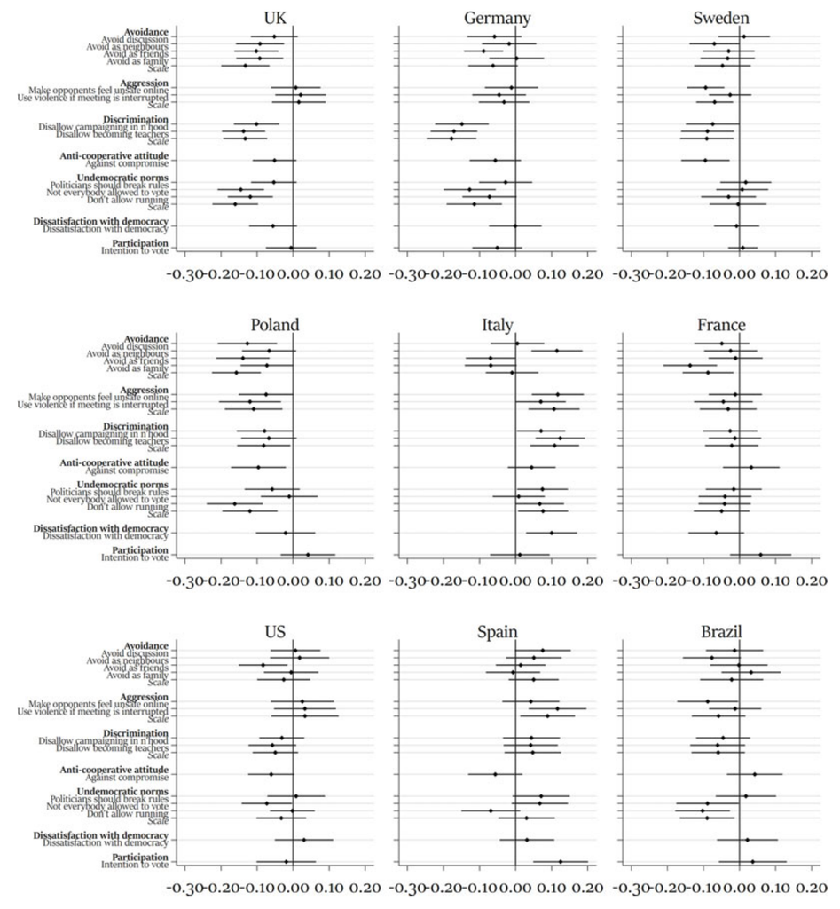

Figure 3: Effects of the depolarizing prompt on each outcome, one panel per country, with the same items as the pooled model. *Source:* Harteveld et al. (2026), Figure 3.

**Note**

**Session 09: who is the out-group?** Where the least-liked camp is a radical right under a cordon sanitaire, denying it rights can feel like the democratic response.

## Conclusion

- Depolarizing improves **interpersonal** outcomes, and in several countries **democratic norms**
- The consequences of AP are **contingent**, not universal
- Limits: one short prompt, effects measured right away
- Item scales are weak: reliability (Cronbach’s α) is 0.53 for avoidance and 0.35 for norms

**Tip**

**For your term paper.** A pre-registration, deviations reported openly, and replication code on OSF.

## Discussion: the silver lining

Turnout **correlates** with AP, but does **not move** when AP is lowered.

- What does that do to the claim that AP **mobilizes** voters?
- What else could produce the correlation?

# Janssen and Turkenburg (2024)

## Introduction

- Some studies find AP **erodes** democratic support, others find **nothing**
- Their answer: everyone assumed a **straight line**
- The relation may be **curvilinear**: an inverted U
- A **research note**: short, the theory sits inside the introduction

## Theory: a sweet spot?

**Too little AP**

- No party one feels **attached** to
- Nothing at stake, so why care about democracy?
- Party identity makes people feel **represented**

**Too much AP**

- The opponent becomes an **enemy**
- Losing becomes unacceptable
- “Partisans first and democrats second”
- Hypothesis: support for democracy is **highest** at moderate AP
- The same shape was found for perceived **ideological** polarization (Torcal and Magalhães 2022)

**Note**

**Session 08: party identity.** The low end rests on partisanship as an attachment, citing Dias and Lelkes (2022) and Orr et al. (2023).

## Research design

- Survey data: **Germany** 2017, **UK** 2017, **US** 2016 (Comparative National Election Project)
- Democratic support: representative democracy, against army rule, one party, a strong leader
- AP: Wagner’s **spread** over party like/dislike ratings
- **Generalized additive models**: the data choose the shape of the curve
- Then a regression with a squared term as a check

**Note**

**Session 05: the spread measure.** Wagner (2021), rated toward **parties** (vertical), whereas Harteveld et al. rate **supporters**.

## Results: an inverted U

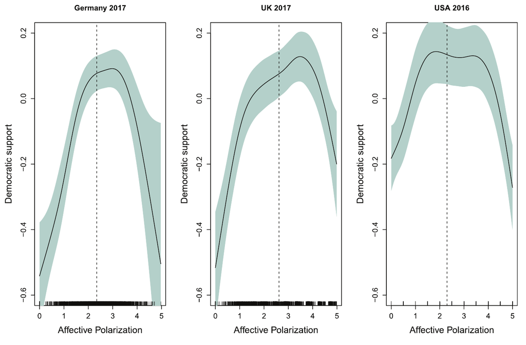

Figure 4: The relationship between party AP (Wagner spread, 0 to 5) and democratic support, estimated with generalized additive models, with 95% confidence bands. The dashed line marks the country’s mean AP. *Source:* Janssen and Turkenburg (2024), Figure 1.

- An **inverted U** in all three countries, flatter at the top in the US
- The average citizen sits **at or before** the peak, not past it

**Your sketch:** who drew a curve?

## If you fit a line

- A **linear** model finds nothing in the US, and a **positive** slope in Germany and the UK
- The squared term fits better in all three
- Robust to other AP measures, to more controls, and to dropping zero scores
- The same curve in the US experiment data of Voelkel et al. (2023)

**Important**

**A null in a linear model is not evidence of no relationship.** Check the shape before you fit a line.

## The left end

Who scores **zero** on AP?

- Someone who rates **every** party the same
- Often: someone who rates every party **zero**
- That is **disillusionment**, not calm

**Important**

**Session 05: the measure decides what “low AP” means.** With both components, someone who dislikes every party has no in-group warmth, and so no AP. The authors drop these respondents as a check, and the curve survives.

## Conclusion

- A **sweet spot**: enough AP to care, not so much that the other side becomes an enemy
- Worry about the **extremes**, not the average
- Limits: three countries, one point in time
- Cross-sectional, so the arrow may run **the other way**

**Note**

**Session 06: no random assignment, no causal claim.** Weak democratic support may come first and flatten party ratings.

# Part 3: What holds up?

## The evidence grid

For each outcome: does it **correlate** with AP, and does it **move** when AP is lowered?

Table 2: What holds up, combining Harteveld et al. (2026) (rows 1 to 4) and Janssen and Turkenburg (2024) (row 5).

| Outcome | Correlates with AP | Moves when AP is lowered | Verdict |
| --- | --- | --- | --- |
| Avoidance, discrimination | yes | yes | Holds up best |
| Democratic norms | yes | partly | Depends on the country |
| Aggression | yes | no | Rare, close to the floor |
| Dissatisfaction, turnout | yes | no | Correlation only |
| Democratic support overall | inverted U | not tested | Depends on the shape |

## Can both be true?

Two ways a widely shared claim fails, even when the correlations are real:

- **Causation**: lowering AP changes some outcomes, not all (Harteveld et al. 2026)
- **Shape**: more AP is not always worse (Janssen and Turkenburg 2024)
- Both papers: resist both **alarmism** and **complacency**

**Tip**

**For your term paper.** Ask whether your correlation is a cause, check the shape before fitting a line, and share your code.

# Wrap-up

## Recap: takeaways

- The alarm rests on **threat** and **politicized norms**, and mostly on correlations
- Lowering AP reduces **avoidance** and **discrimination**, and in some countries strengthens **norms**
- Effects depend on **context**: little in the US, less where the out-group is stigmatized
- The relation with democratic support looks like an **inverted U**, not a line
- What “low AP” means depends on the **measure**

## Recap: learning goals

**Goal 1. Why AP should harm democracy**

- Threat makes people deny rights to the other side, and hostility makes them apply democratic norms only when it suits their side

**Goal 2. Consequences studied, and how**

- Horizontal: avoidance, discrimination, aggression. Vertical: compromise, norms, satisfaction, turnout, democratic support
- A depolarizing survey experiment in nine countries, and survey data with flexible curves in three

**Goal 3. What holds up**

- Avoidance and discrimination hold up, norms depend on the country, turnout and satisfaction are correlation only
- The direction of the relation depends on where people sit on the curve and on how AP is measured

## Next session

- **Session 11: Term paper pitches I**, 2 December
- If you were scheduled for 25 November, you present **next week**
- A research question, why it matters, a design, and your data
- Ideally, your pitch follows the **magic five**:
  1. **Introduction**: your research question, and why it matters
  2. **Theory**: your argument, and what you expect
  3. **Research design**: how you will answer the question
  4. **Results**: what form your results will take
  5. **Conclusion**: what can and cannot be learned from it, and its limits

## References

Broockman, David E., Joshua L. Kalla, and Sean J. Westwood. 2023. “Does Affective Polarization Undermine Democratic Norms or Accountability? Maybe Not.” *American Journal of Political Science* 67 (3): 1–21. https://doi.org/10.1111/ajps.12719.

Dias, Nicholas, and Yphtach Lelkes. 2022. “The Nature of Affective Polarization: Disentangling Policy Disagreement from Partisan Identity.” *American Journal of Political Science* 66 (3): 775–90. https://doi.org/10.1111/ajps.12628.

Druckman, James, and Matthew Levendusky. 2019. “What Do We Measure When We Measure Affective Polarization?” *Public Opinion Quarterly* 83 (1): 114–22. https://doi.org/10.1093/poq/nfz003.

Graham, Matthew H., and Milan W. Svolik. 2020. “Democracy in America? Partisanship, Polarization, and the Robustness of Support for Democracy in the United States.” *American Political Science Review* 114 (2): 392–409. https://doi.org/10.1017/S0003055420000052.

Harteveld, Eelco, Lars Erik Berntzen, Andrej Kokkonen, Haylee Kelsall, Jonas Linde, and Stefan Dahlberg. 2026. “The (Alleged) Consequences of Affective Polarization: A Survey Experiment in Nine Democracies.” *European Journal of Political Research*, 1–19. https://doi.org/10.1017/S1475676526101273.

Janssen, Lisa, and Emma Turkenburg. 2024. “Breaking Free from Linear Assumptions: Unravelling the Relationship Between Affective Polarization and Democratic Support.” *European Journal of Political Research* 64: 1465–2479. https://doi.org/10.1111/1475-6765.12725.

Kingzette, Jon, James N. Druckman, Samara Klar, Yanna Krupnikov, Matthew Levendusky, and John Barry Ryan. 2021. “How Affective Polarization Undermines Support for Democratic Norms.” *Public Opinion Quarterly* 85 (2): 663–77. https://doi.org/10.1093/poq/nfab029.

McCoy, Jennifer, Tahmina Rahman, and Murat Somer. 2018. “Polarization and the Global Crisis of Democracy: Common Patterns, Dynamics, and Pernicious Consequences for Democratic Polities.” *American Behavioral Scientist* 62 (1): 16–42. https://doi.org/10.1177/0002764218759576.

Orr, Lilla V., Anthony Fowler, and Gregory A. Huber. 2023. “Is Affective Polarization Driven by Identity, Loyalty, or Substance?” *American Journal of Political Science* 67 (4): 948–62. https://doi.org/10.1111/ajps.12796.

Torcal, Mariano, and Pedro C. Magalhães. 2022. “Ideological Extremism, Perceived Party System Polarization, and Support for Democracy.” *European Political Science Review* 14 (2): 188–205. https://doi.org/10.1017/s1755773922000066.

Voelkel, Jan G., James Chu, Michael N. Stagnaro, et al. 2023. “Interventions Reducing Affective Polarization Do Not Necessarily Improve Anti-Democratic Attitudes.” *Nature Human Behaviour* 7 (1): 55–64. https://doi.org/10.1038/s41562-022-01466-9.

Wagner, Markus. 2021. “Affective Polarization in Multiparty Systems.” *Electoral Studies* 69: 102199. https://doi.org/10.1016/j.electstud.2020.102199.